# Determination of Normal CI in 2nd and 3rd Trimester: Sample population

Usman

2023-10-22

## 0.1 **R Markdown**

# 1 **Objective**

1. Estimation of fetal cephalic index among Hausa/Fulani pregnant women in Rano LGA, Kano State.
2. Study the difference between 2nd and 3rd-trimester cephalic index values for both male and female
3. Assess possible association between sex and various obstetric parameters
4. Correlate the different fetal biometric parameters and gestational age to determine the best predictor

## 1.1 **Inclusion criteria**:

- Singleton pregnancy. Dichorionic pregnancies with demise of 1 fetus in the first trimester were included
- Formal pregnancy ultrasound performed at WCH at 28 to 33 weeks, including standard fetal biometry.
- Morphology ultrasound performed at 17 to 22 weeks’ gestation at WCH or another accredited images for review.

```r
library(readxl)
cephalic <- read_excel("~/Bluetooth Exchange Folder/sagagi2.xlsx",sheet = "Sheet2")
cephalic
```

```
## # A tibble: 631 × 9
##       ID SEX     BPD   OFD    FL    AC    CI EG.A  TRIMESTER
##    <dbl> <chr> <dbl> <dbl> <dbl> <dbl> <dbl> <chr> <chr>
##  1     1 F        93   113    78   360    82 39+2  3RD
##  2     2 M        91   108    72   338    84 37+0  3RD
##  3     3 M        56    64    41   182    88 22+5  2ND
##  4     4 F        52    62    38   183    84 22+0  2ND
##  5     5 M        87   106    69   332    82 35+5  3RD
##  6     6 F        83   101    64   296    82 33+1  3RD
##  7     7 M        76    87    55   252    87 29+1  3RD
##  8     8 F        69    83    53   242    83 27+4  3RD
##  9     9 M        72    86    52   249    84 28+2  3RD
## 10    10 M        71    83    49   236    86 27+2  3RD
## # ℹ 621 more rows
```

## 1.2 Figures, Code chunks, and Logistic regression tables

### 1.2.1 **Figure 1**

```r
library(tidyverse)
```

```r
library(ggpubr)
#library(ggpubr) and library(tidyverse)
# Vertical and Horizontal median representation of both variables
#scatterplot showing correlation BPD and OFD at 2nd Trimester
meanbpd2<-cephalic%>%mutate(EG.A=str_replace_all(EG.A,"[+]","."),TRIMESTER=recode(TRIMESTER,"2nd"="2ND","3rd"="3RD",
  "2NDF"="2ND"))%>%filter(TRIMESTER=="2ND")%>%summarise(median_val=median(BPD))
meanbpd2
```

```
## # A tibble: 1 × 1
##   median_val
##        <dbl>
## 1         57
```

```r
meanofd2<-cephalic%>%mutate(EG.A=str_replace_all(EG.A,"[+]","."),TRIMESTER=recode(TRIMESTER,"2nd"="2ND","3rd"="3RD",
"2NDF"="2ND"))%>%filter(TRIMESTER=="2ND")%>%summarise(median_val=median(OFD))
meanofd2
```

```
## # A tibble: 1 × 1
##   median_val
##        <dbl>
## 1         68
```

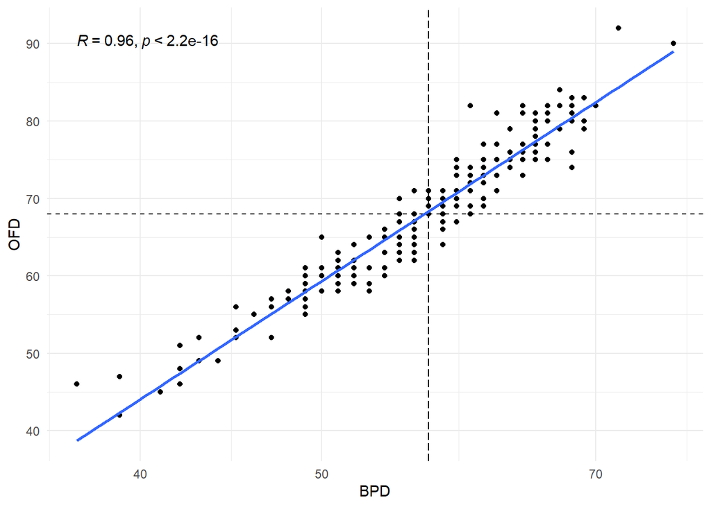

```r
cephalic%>%mutate(EG.A=str_replace_all(EG.A,"[+]","."),TRIMESTER=recode(TRIMESTER,"2nd"="2ND","3rd"="3RD","2NDF"="2ND"))%>%
  filter(TRIMESTER=="2ND")%>%ggplot(aes(BPD,OFD))+geom_point()+theme_minimal()+
  geom_hline(data= meanofd2, aes(yintercept = median_val),linetype="dashed")+
  geom_vline(data= meanbpd2, aes(xintercept = median_val),linetype="longdash")+geom_smooth(method = lm,se=FALSE,fullrange=TRUE)+
  scale_x_log10()+stat_cor(method = "spearman")
```

### 1.2.2 **Figure 2**

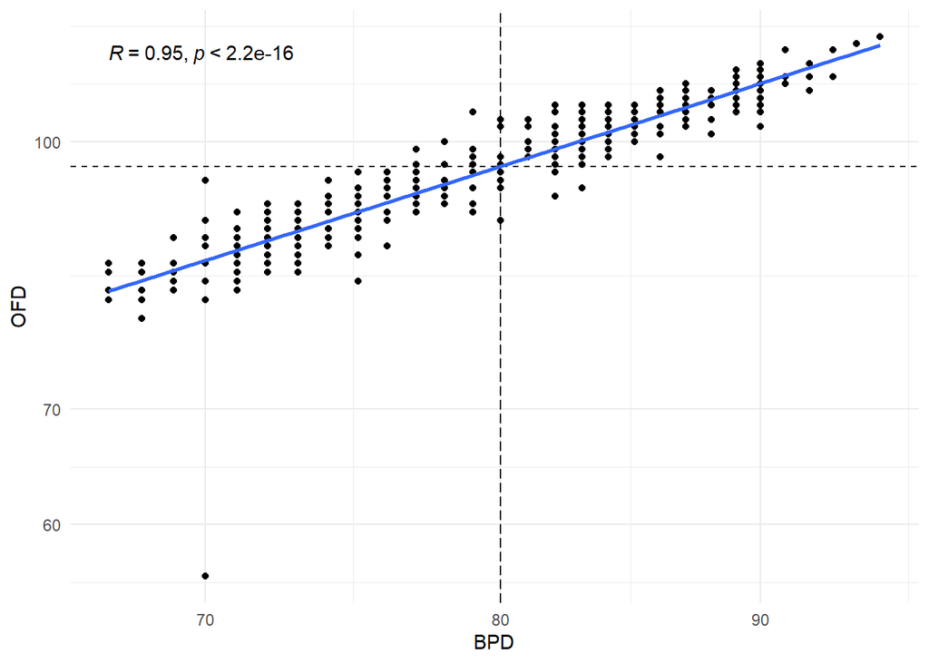

```r
meanbpd3<-cephalic%>%mutate(EG.A=str_replace_all(EG.A,"[+]","."),
  TRIMESTER=recode(TRIMESTER,"2nd"="2ND","3rd"="3RD","2NDF"="2ND"))%>%
  filter(TRIMESTER=="3RD")%>%
  summarise(median_val=median(BPD))

meanofd3<-cephalic%>%mutate(EG.A=str_replace_all(EG.A,"[+]","."),
                        TRIMESTER=recode(TRIMESTER,"2nd"="2ND","3rd"="3RD",
                        "2NDF"="2ND"))%>%filter(TRIMESTER=="3RD")%>%
                         summarise(median_val=mean(OFD))


cephalic%>%mutate(EG.A=str_replace_all(EG.A,"[+]","."),TRIMESTER=recode(TRIMESTER,"2nd"="2ND","3rd"="3RD","2NDF"="2ND"))%>%
  filter(TRIMESTER=="3RD")%>%ggplot(aes(BPD,OFD))+
  geom_point()+theme_minimal()+
  geom_hline(data= meanofd3, aes(yintercept = median_val),linetype="dashed")+
  geom_vline(data= meanbpd3, aes(xintercept = median_val),linetype="longdash")+
  geom_smooth(method = lm,se=FALSE,fullrange=TRUE)+scale_x_log10()+scale_y_log10()+
  stat_cor(method = "spearman")
```

### 1.2.3 **Figure 3**

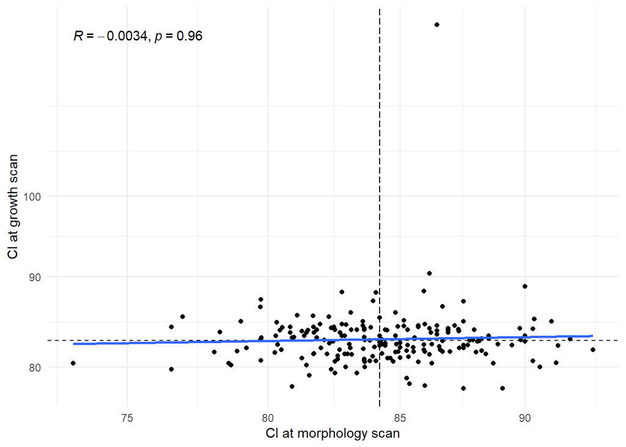

```r
#Scatter plot of the cephalic index at the growth scan versus the cephalic index at the morphology scan
ci_morho<-cephalic%>%mutate(EG.A1=str_replace_all(EG.A,"[+]","."),
  TRIMESTER=recode(TRIMESTER,"2nd"="2ND","3rd"="3RD","2NDF"="2ND"))%>%
  mutate(CI3=(BPD/OFD)*100)%>%filter(TRIMESTER=="3RD")%>%
  select(TRIMESTER,CI3,EG.A1)
ci_growth<-cephalic%>%mutate(EG.A=str_replace_all(EG.A,"[+]","."),
  TRIMESTER=recode(TRIMESTER,"2nd"="2ND","3rd"="3RD","2NDF"="2ND"))%>%
  mutate(CI2=(BPD/OFD)*100)%>%filter(TRIMESTER=="2ND")

ci_medianM<-tibble(ci_growth,CI3=ci_morho[-c(199:433),]$CI3)%>%
  summarise(median_val=median(CI2))

ci_medianG<-tibble(ci_growth,CI3=ci_morho[-c(199:433),]$CI3)%>%
  summarise(median_val=median(CI3))

tibble(ci_growth,CI3=ci_morho[-c(199:433),]$CI3)%>%ggplot(aes(CI2,CI3))+
  geom_point()+theme_minimal()+scale_x_log10()+scale_y_log10()+
  labs(x="CI at morphology scan",y="CI at growth scan")+
  geom_hline(data= ci_medianG, aes(yintercept = median_val),linetype="dashed")+
  geom_vline(data= ci_medianM, aes(xintercept = median_val),linetype="longdash")+
  geom_smooth(method = lm,se=FALSE,fullrange=TRUE)+stat_cor(method = "spearman")
```

**Figure 3**: Scatter plot of the cephalic index at the growth scan versus the cephalic index at the morphology scan, showing little difference between the 2 groups.

### 1.2.4 **Figure 4**

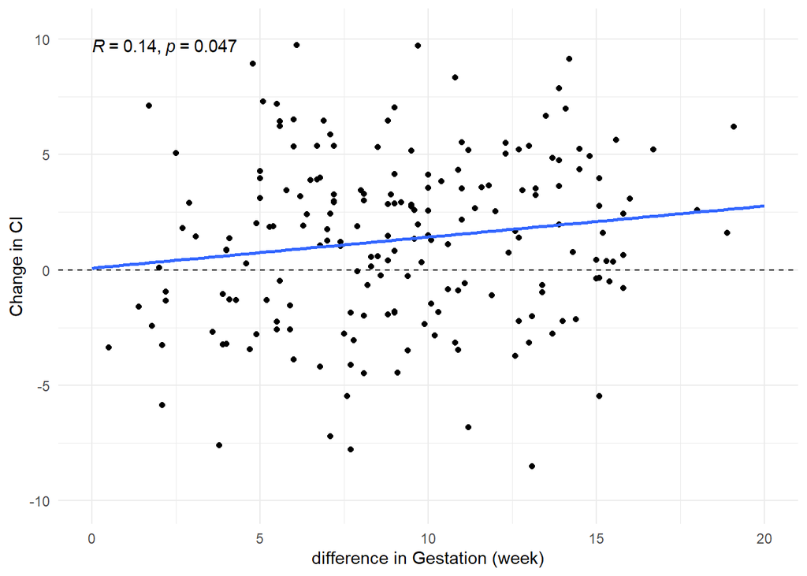

```r
ci_growth1<-cephalic%>%mutate(EG.A=str_replace_all(EG.A,"[+]","."),
  TRIMESTER=recode(TRIMESTER,"2nd"="2ND","3rd"="3RD","2NDF"="2ND"))%>%
  mutate(CI2=(BPD/OFD)*100)%>%filter(TRIMESTER=="2ND")%>%
  mutate(CI3=CI2)%>%select(TRIMESTER,CI3,EG.A)

ci_morpho<-cephalic%>%mutate(EG.A1=str_replace_all(EG.A,"[+]","."),
  TRIMESTER=recode(TRIMESTER,"2nd"="2ND","3rd"="3RD","2NDF"="2ND"))%>%
  mutate(CI2=(BPD/OFD)*100)%>%filter(TRIMESTER=="3RD")%>%
  select(TRIMESTER,CI2,EG.A1)

ci_morpho$EG.A1<-as.numeric(ci_morpho$EG.A1)
ci_growth1$EG.A<-as.numeric(ci_growth1$EG.A)

new_data<-tibble(ci_growth1[,-1],ci_morpho[-c(199:433),])%>%
  mutate(gest_dif_wk= ci_morpho[-c(199:433),]$EG.A1-ci_growth1[,-1]$EG.A,ci_change=CI3-CI2)

new_data%>%ggplot(aes(gest_dif_wk,ci_change))+
  geom_point()+geom_smooth(method = lm,se=FALSE,fullrange=TRUE)+
  stat_cor(method = "spearman")+scale_y_continuous(limits = c(-10,10.3))+
  scale_x_continuous(limits = c(0,20))+geom_hline(yintercept = 0, linetype="dashed")+
  theme_minimal()+labs(x="difference in Gestation (week)", y= "Change in CI")
```

**Figure 4**: Scatter plot of the change in cephalic index between growth and morphology scans versus the corresponding change in gestation age; the blue solid line shows the linear regression line; the dash tick line is a reference line for zero change in CI.

### 1.2.5 **Figure 5**

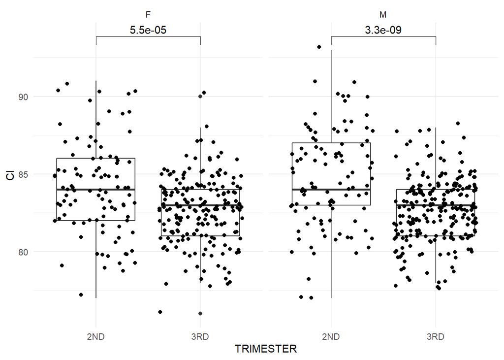

```r
#comparing means and adding to our figure
my_comparisons<-list(c("2ND","3RD"))

cephalic%>%mutate(TRIMESTER=recode(TRIMESTER,"2nd"="2ND","3rd"="3RD","2NDF"="2ND"))%>%
  ggplot(aes(TRIMESTER,CI))+geom_boxplot()+geom_point(position=position_jitter())+
  theme_minimal()+stat_compare_means(comparisons = my_comparisons)+facet_wrap(~SEX)
```

**Figure 5**: Comparison between group relative to gender

### 1.2.6 **Figure 6**: using ‘ggpairs()’

```r
library(GGally)
```

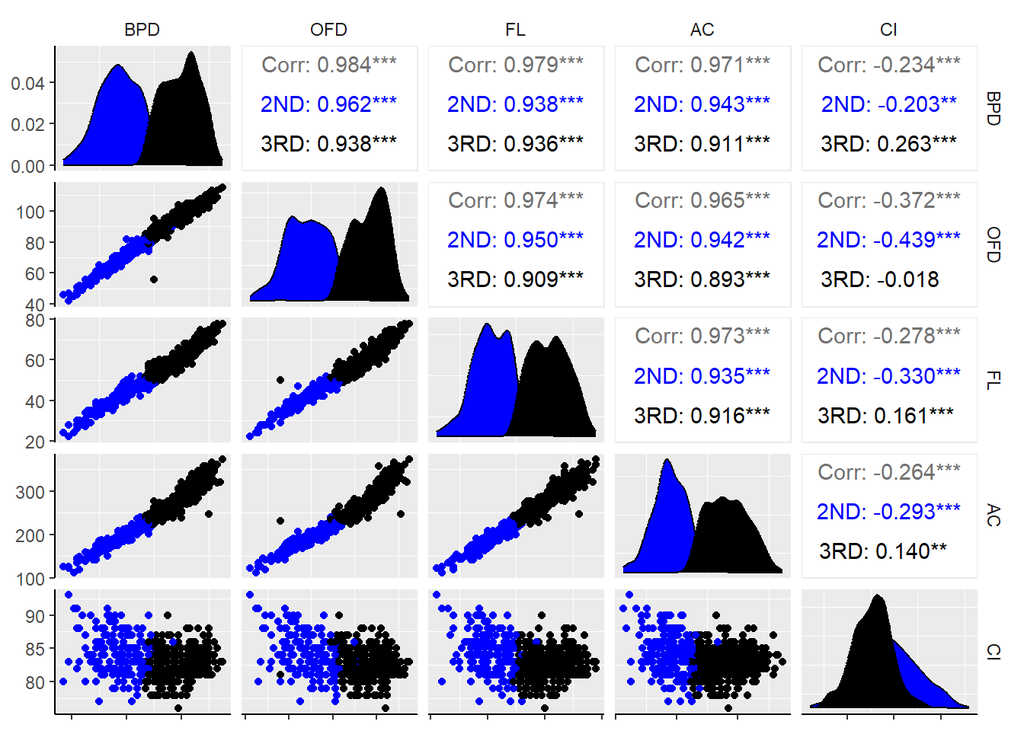

```r
#pairwise comparisons between morphology and growth variables
cephalic%>%mutate(TRIMESTER=recode(TRIMESTER,"2nd"="2ND","3rd"="3RD","2NDF"="2ND"))%>%
  ggpairs(columns=3:7,aes(col=TRIMESTER))+theme(panel.grid.major = element_blank(),
  axis.line = element_line(colour = "black"))+
  theme(strip.background = element_rect(fill = "white"),strip.placement = "outside")+
  theme(axis.text.x = element_blank())+scale_color_manual(values=c("blue","black"))+
  scale_fill_manual(values=c("blue","black"))
```

**Figure 6** Correlation matrix

### 1.2.7 **Logistic regression analysis**

```r
#logistic regression analysis
cephalic$sex<-cephalic$SEX
cephalic$logit<-cephalic$TRIMESTER
cephalic[cephalic$logit=="2ND"|cephalic$logit=="2nd"|cephalic$logit=="2NDF",]$logit<-"0"
cephalic[cephalic$logit=="3RD"|cephalic$logit=="3rd",]$logit<-"1"
cephalic[cephalic$sex=="F",]$sex<-"0"
cephalic[cephalic$sex=="M",]$sex<-"1"
cephalic$logit<-as.factor(cephalic$logit)
glm(logit~sex, data=cephalic,family = "binomial")
```

```
##
## Call:  glm(formula = logit ~ sex, family = "binomial", data = cephalic)
##
## Coefficients:
## (Intercept)         sex1
##      0.6983       0.1589
##
## Degrees of Freedom: 630 Total (i.e. Null);  629 Residual
## Null Deviance:       785.1
## Residual Deviance: 784.2     AIC: 788.2
```

```r
summary(glm(logit~sex, data=cephalic,family = "binomial"))
```

```
##
## Call:
## glm(formula = logit ~ sex, family = "binomial", data = cephalic)
##
## Deviance Residuals:
##     Min       1Q   Median       3Q      Max
## -1.5562  -1.4846   0.8411   0.8986   0.8986
##
## Coefficients:
##             Estimate Std. Error z value Pr(>|z|)
## (Intercept)   0.6983     0.1242   5.620 1.91e-08 ***
## sex1          0.1589     0.1719   0.924    0.355
## ---
## Signif. codes:  0 '***' 0.001 '**' 0.01 '*' 0.05 '.' 0.1 ' ' 1
##
## (Dispersion parameter for binomial family taken to be 1)
##
##     Null deviance: 785.09  on 630  degrees of freedom
## Residual deviance: 784.23  on 629  degrees of freedom
## AIC: 788.23
##
## Number of Fisher Scoring iterations: 4
```

```r
summary(glm(logit~SEX+BPD+OFD+FL+AC, data=cephalic,family = "binomial"))
```

```
##
## Call:
## glm(formula = logit ~ SEX + BPD + OFD + FL + AC, family = "binomial",
##     data = cephalic)
##
## Deviance Residuals:
##     Min       1Q   Median       3Q      Max
## -4.4158  -0.0002   0.0001   0.0081   1.2359
##
## Coefficients:
##              Estimate Std. Error z value Pr(>|z|)
## (Intercept) -68.15417   11.71000  -5.820 5.88e-09 ***
## SEXM         -0.03079    0.62357  -0.049   0.9606
## BPD           0.42833    0.16727   2.561   0.0104 *
## OFD           0.02380    0.06676   0.356   0.7215
## FL            0.36608    0.17408   2.103   0.0355 *
## AC            0.08219    0.03847   2.136   0.0327 *
## ---
## Signif. codes:  0 '***' 0.001 '**' 0.01 '*' 0.05 '.' 0.1 ' ' 1
##
## (Dispersion parameter for binomial family taken to be 1)
##
##     Null deviance: 785.087  on 630  degrees of freedom
## Residual deviance:  74.213  on 625  degrees of freedom
## AIC: 86.213
##
## Number of Fisher Scoring iterations: 10
```